# Exploring Weather Trends - Project Instructions

### Summary

In this project, you will analyze local and global temperature data and compare the temperature trends where you live to overall global temperature trends.

### Instructions

Your goal will be to create a visualization and prepare a write up describing the similarities and differences between global temperature trends and temperature trends in the closest big city to where you live. To do this, you'll follow the steps below:

- Extract the data from the database. There's a workspace in the previous section that is connected to a database. You'll need to export the temperature data for the world as well as for the closest big city to where you live. You can find a list of cities and countries in the `city_list` table. To interact with the database, you'll need to write a SQL query.
  - Write a SQL query to extract the city level data. Export to CSV.
  - Write a SQL query to extract the global data. Export to CSV.
- Open up the CSV in whatever tool you feel most comfortable using. We suggest using Excel or Google sheets, but you are welcome to use another tool, such as Python or R.
- Create a line chart that compares your city's temperatures with the global temperatures. Make sure to plot the *moving average* rather than the yearly averages in order to smooth out the lines, making trends more observable (the last concept in the previous lesson goes over how to do this in a spreadsheet).
- Make observations about the similarities and differences between the world averages and your city's averages, as well as overall trends. Here are some questions to get you started.
  - Is your city hotter or cooler on average compared to the global average? Has the difference been consistent over time?
  - "How do the changes in your city's temperatures over time compare to the changes in the global average?"
  - What does the overall trend look like? Is the world getting hotter or cooler? Has the trend been consistent over the last few hundred years?

### Submission

Your submission should be a PDF that includes:

- An outline of steps taken to prepare the data to be visualized in the chart, such as:
  - What tools did you use for each step? (Python, SQL, Excel, etc)
  - How did you calculate the moving average?
  - What were your key considerations when deciding how to visualize the trends?
- Line chart with local and global temperature trends
- At least four observations about the similarities and/or differences in the trends

### Rubric

A Udacity reviewer will assess your project based on the criteria in the [project rubric](https://review.udacity.com/#!/rubrics/3038/view). Use the rubric as a guide while you complete the project, then give yourself a quick self-assessment before you submit it.

If you're on this page, then you should have completed your exploration of local and global temperature trends. Congratulations! Before you submit your project, make sure to check the following points:

- Please submit your project as a PDF. Your report should include documentation of the steps in your analysis, a line chart depicting the local and global temperature data, and your observations regarding the trends.
- Don't forget to review the [rubric](https://review.udacity.com/#!/rubrics/3038/view)! Reviewers will use the rubric to assess your work, so make sure it 'meets specifications' on all points before you submit.

Once you've checked the above, click on the "Submit Project" button below to go to the project submission page. After you submit your project, it can take up to a week for it to be evaluated. Most of the time, it is much faster! In the meantime, you can feel free to continue to other parts of the program to continue your learning!

# Project 1 - Larijohn Adorable

## Tools Used

- Jupyter Lab, python3, pandas, seaborn, matplotlib, numpy, PostgresSQL

## 1. Extract the data using SQL and exporting it to a CSV

- I was able to import the csv's into my own local postgres database
- Use SQL to dump the tables city_data, city_list, global_data into a csv. I also imported it into my own local db in case I needed to do some EDA (Exploratory Data Analysis) from there

```python
# Extract and Load data into PostgresSQL Database as well as Pandas Dataframes
from sqlalchemy import create_engine
import pandas as pd
import os

db = os.environ.get('LDB')
engine = create_engine(db)

# read csvs into pandas
cd = pd.read_csv('city_data.csv')
cl = pd.read_csv('city_list.csv')
gd = pd.read_csv('global_data.csv')

# create and insert tables into my postgresdb
#cd.to_sql('city_data', engine)
#cl.to_sql('city_list', engine)
#gd.to_sql('global_data', engine)
```

```python
# Here is an example of how I could query the database from jupyter lab
city_data_s = %sql $db select * from city_data
city_list_s = %sql $db select * from city_list
global_data_s = %sql $db select * from global_data

cd = city_data_s.DataFrame()
cl = city_list_s.DataFrame()
gl = global_data_s.DataFrame()
```

```
70792 rows affected.
342 rows affected.
266 rows affected.
```

```python
# Add city_id as a column, this will be merged into the city_data dataframe. This was performed because it is easier to reference and group by a city, country combination. City names are not unique globally
cl['city_id'] = cl.index
cl = cl.reindex(columns=['city_id', 'city','country'])
print(cl.head(3))
print(cl.shape)
```

```
   city_id       city               country
0        0    Abidjan         Côte D'Ivoire
1        1  Abu Dhabi  United Arab Emirates
2        2      Abuja               Nigeria
(342, 3)
```

```python
# Afterwards, merge city_id column into city_data (cd) dataframe
cd = pd.merge(cl, cd, left_on=['city','country'],right_on=['city','country'])
```

```python
# The list below demonstrates how city names are not unique globally. Therefore, I needed to add the city_id column
city_value_counts = cl.city.value_counts()
city_value_counts[city_value_counts > 1]
```

```
Santiago         3
Hyderabad        2
Santo Domingo    2
London           2
Barcelona        2
Alexandria       2
Colombo          2
Los Angeles      2
Kingston         2
Birmingham       2
La Paz           2
Valencia         2
Name: city, dtype: int64
```

```python
# Next I added an avg_temp_f (Fareinheit) column, since I am not familiar with Celius as an American
# and find it easier to compare temperatures across the world, to a temperature classification medium I am familiar with
def convertC_to_F(c_temp):
     return c_temp * (9/5)+32

cd['avg_temp_f'] = cd.avg_temp.dropna().apply(lambda x : convertC_to_F(x))
gd['avg_temp_f'] = gd.avg_temp.dropna().apply(lambda x : convertC_to_F(x))
print(cd.head(3))
print(gd.head(3))
```

```
   city_id     city        country  year  avg_temp  avg_temp_f
0        0  Abidjan  Côte D'Ivoire  1849     25.58      78.044
1        0  Abidjan  Côte D'Ivoire  1850     25.52      77.936
2        0  Abidjan  Côte D'Ivoire  1851     25.67      78.206
   year  avg_temp  avg_temp_f
0  1750      8.72      47.696
1  1751      7.98      46.364
2  1752      5.78      42.404
```

### Next, in order to calculate moving averages data per city, I performed the steps below.

1. Grouped City Data by City_ID
2. For each city_group, calculate the rolling averages (10 year and 25 year) as set them as new columns in the temporary cg dataframe, which is just the grouped city dataframe
3. Merged the rows of the temporary cg dataframe back into cd using loc, such that I only update the columns which are part of that row/index subset

```python
# The difference between my solution above and Sertac's solution is that the transform allows to run an apply on a group of dataframe rows, where as I was not familiar with the
# transform function.

## Vectorized solution provided by Sertac Ozker https://knowledge.udacity.com/questions/500117
cd.sort_values(by=['city_id', 'year'], inplace=True)

cd['MA10_C'] = cd.groupby('city_id')['avg_temp'].transform(lambda x: x.rolling(10,1).mean())
cd['MA10_F'] = cd.groupby('city_id')['avg_temp_f'].transform(lambda x: x.rolling(10,1).mean())
cd['MA25_C'] = cd.groupby('city_id')['avg_temp'].transform(lambda x: x.rolling(25,1).mean())
cd['MA25_F'] = cd.groupby('city_id')['avg_temp_f'].transform(lambda x: x.rolling(25,1).mean())

# Perform moving average on global average dataset as well
gd['MA10_C'] = gd.avg_temp.rolling(10,1).mean()
gd['MA25_C'] = gd.avg_temp.rolling(25,1).mean()
gd['MA10_F'] = gd.avg_temp_f.rolling(10,1).mean()
gd['MA25_F'] = gd.avg_temp_f.rolling(25,1).mean()
```

> ```
> # Method below deprecated by cell above, answered by Sertac Ozker, Udacity DA mentor
> for index, cg in cdgb:
>     cg['MA10_C'] = cg[cg.city_id == cg.city_id].avg_temp.rolling(window=10).mean()
>     cg['MA25_C'] = cg[cg.city_id == cg.city_id].avg_temp.rolling(window=25).mean()
>     cg['MA10_F'] = cg[cg.city_id == cg.city_id].avg_temp_f.rolling(window=10).mean()
>     cg['MA25_F'] = cg[cg.city_id == cg.city_id].avg_temp_f.rolling(window=25).mean()
>     cd.loc[cg.index, 'MA10_C'] = cg['MA10_C']
>     cd.loc[cg.index, 'MA25_C'] = cg['MA25_C']
>     cd.loc[cg.index, 'MA10_F'] = cg['MA10_F']
>     cd.loc[cg.index, 'MA25_F'] = cg['MA25_F']
>
> # Calculate Moving Averages for Global Data below
> gd['MA10_C'] = gd.avg_temp.rolling(window=10).mean()
> gd['MA25_C'] = gd.avg_temp.rolling(window=25).mean()
> gd['MA10_F'] = gd.avg_temp_f.rolling(window=10).mean()
> gd['MA25_F'] = gd.avg_temp_f.rolling(window=25).mean()
> ```

# Graph 1: Plot of Graph San Francisco vs Global Weather Trends

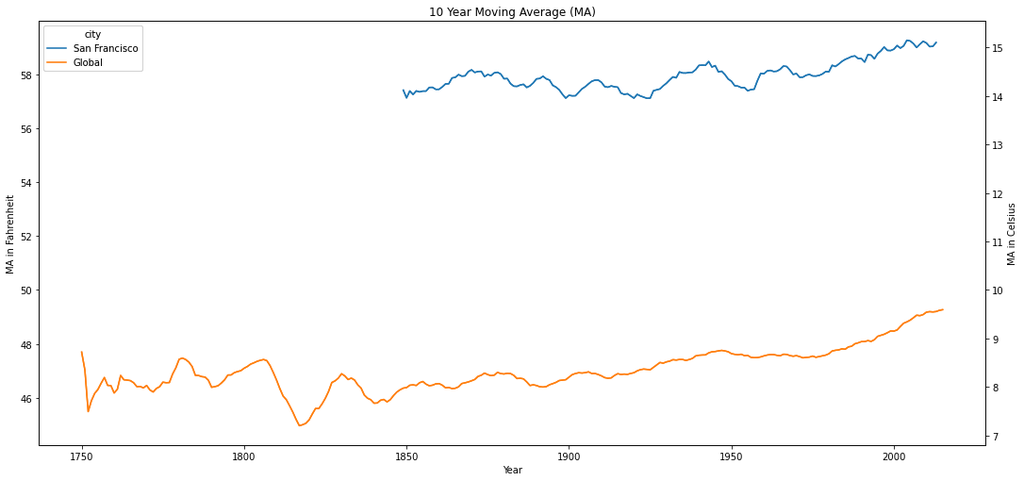

```python
import pandas as pd
import seaborn as sns
import matplotlib.pyplot as plt

a4_dims = (18, 8.27)
fig, ax = plt.subplots(figsize= a4_dims)

# Graph San Francisco vs Global Weather Trends
city = 'San Francisco'
df = cd[cd.city == 'San Francisco']
mdf = gd
mdf['city'] ='Global'
mdf = pd.concat([df,gd])

plt.title("10 Year Moving Average (MA)")

plt.xlabel('Year')
plt.ylabel('MA in Fahrenheit')
sns.lineplot(x = mdf.year
             , y = mdf.MA10_F
             , data=mdf
             , ci=None
             , color='b'
             , hue='city'
            )
ax2 = plt.twinx()
plt.ylabel('MA in Celsius')
sns.lineplot(x = mdf.year
             , y = mdf.MA10_C
             , data=mdf
             , ci=None
             , color='r'
             , hue='city'
            )
plt.show()
```

### Insights on Graph 1

- My city, San Francisco is warmer than the global average
- Since approximately 1925, both San Francisco and world's temperatures have increased on average year-by-year

##### To provide further evidence, I decided to use a Seaborn regression plot to fit the data trends onto a line and to provide further confidence that the temperature is increasing

## Graph 2 : Plot a regression plot for San Francisco vs Global Trends

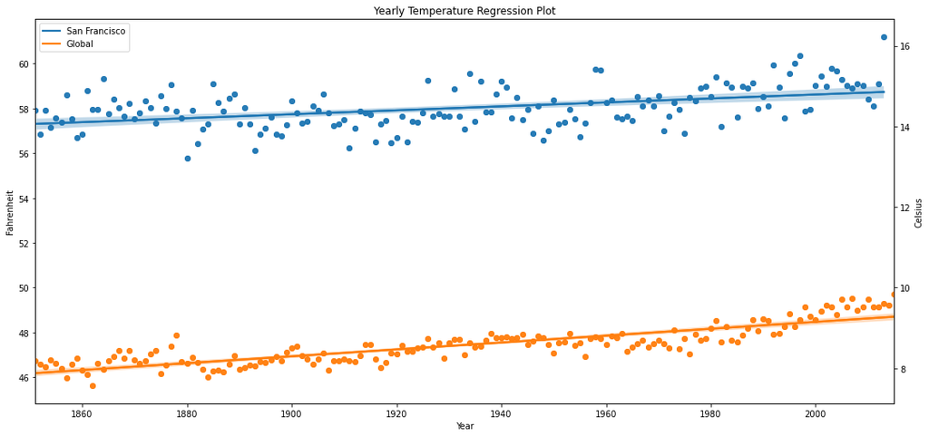

```python
fig, ax = plt.subplots(figsize= a4_dims)

city = 'San Francisco'

df = cd[(cd.city == 'San Francisco') & (cd.year > 1850)]

mdf['city'] = 'Global'
mdf_gt_1900 = gd[gd.year > 1850]

plt.title("Yearly Temperature Regression Plot")
sns.regplot(x = df.year
             , y = df.avg_temp_f
             , data=df )
sns.regplot(x = mdf_gt_1900.year
             , y = mdf_gt_1900.avg_temp_f
             , data=mdf_gt_1900 )

plt.ylabel('Fahrenheit')
plt.xlabel('Year')
ax2 = ax.twinx()
sns.regplot(x = df.year
             , y = df.avg_temp
             , data=df )
sns.regplot(x = mdf_gt_1900.year
             , y = mdf_gt_1900.avg_temp
             , data=mdf_gt_1900 )

plt.ylabel('Celsius')
plt.legend([city, 'Global'])
plt.show()
```

##### The plot above clearly shows that both San Francisco and the Global temperature has been rising for the last couple hundred years.

##### Also, it shows that the differerence between both San Francisco and the Global average temperatures, year-by-year, remain generally the same, however, they tend to slight be more similar in more recent years.

### Next, I will get all the 'best cities' in the world from wikipedia to compare the same findings across many of the 'best cities'

#### Note that the best cities are defined by the following criteria as stated in [Wikipedia: Global City](https://en.wikipedia.org/wiki/Global_city#The_World\'s_Best_Cities)

- A variety of international financial services,[10] notably in finance, insurance, real estate, banking, accountancy, and marketing
- Headquarters of several multinational corporations
- The existence of financial headquarters, a stock exchange, and major financial institutions
- Domination of the trade and economy of a large surrounding area
- Major manufacturing centres with port and container facilities
- Considerable decision-making power on a daily basis and at a global level
- Centres of new ideas and innovation in business, economics, culture, and politics
- Centres of media and communications for global networks
- Dominance of the national region with great international significance
- High percentage of residents employed in the services sector and information sector
- High-quality educational institutions, including renowned universities, international student attendance,[11] and research facilities
- Multi-functional infrastructure offering some of the best legal, medical, and entertainment facilities in the country
- High diversity in language, culture, religion, and ideologies

```python
best_cities = pd.read_html('https://en.wikipedia.org/wiki/Global_city#The_World\'s_Best_Cities')
best_cities[0].City
```

```
0          New York
1            London
2             Tokyo
3         Hong Kong
4             Paris
5         Singapore
6       Los Angeles
7          Shanghai
8           Beijing
9             Seoul
10          Chicago
11    San Francisco
12          Toronto
13           Sydney
14           Berlin
15           Boston
16           Moscow
17        Amsterdam
18            Dubai
19         Istanbul
Name: City, dtype: object
```

##### The list of cities below are the cities found both in the city_list dataset and the world cities list from wikipedia

- I noticed the following cities are missing
  - Hong Kong
  - Dubai
  - Beijing

```python
best_cities = cl[cl.city.isin(best_cities[0].City.to_list())]
best_cities
```

|  | city_id | city | country |
| --- | --- | --- | --- |
| 15 | 15 | Amsterdam | Netherlands |
| 42 | 42 | Berlin | Germany |
| 48 | 48 | Boston | United States |
| 69 | 69 | Chicago | United States |
| 132 | 132 | Istanbul | Turkey |
| 173 | 173 | London | Canada |
| 174 | 174 | London | United Kingdom |
| 176 | 176 | Los Angeles | Chile |
| 177 | 177 | Los Angeles | United States |
| 211 | 211 | Moscow | Russia |
| 224 | 224 | New York | United States |
| 237 | 237 | Paris | France |
| 275 | 275 | San Francisco | United States |
| 287 | 287 | Seoul | South Korea |
| 288 | 288 | Shanghai | China |
| 292 | 292 | Singapore | Singapore |
| 300 | 300 | Sydney | Australia |
| 311 | 311 | Tokyo | Japan |
| 312 | 312 | Toronto | Canada |

```python
# Since there are two Los Angeles and two London cities in the world, I need to remove their duplicates from this list
best_cities = best_cities[~best_cities.city_id.isin([176,173])].sort_values(by='city')
best_cities
```

|  | city_id | city | country |
| --- | --- | --- | --- |
| 15 | 15 | Amsterdam | Netherlands |
| 42 | 42 | Berlin | Germany |
| 48 | 48 | Boston | United States |
| 69 | 69 | Chicago | United States |
| 132 | 132 | Istanbul | Turkey |
| 174 | 174 | London | United Kingdom |
| 177 | 177 | Los Angeles | United States |
| 211 | 211 | Moscow | Russia |
| 224 | 224 | New York | United States |
| 237 | 237 | Paris | France |
| 275 | 275 | San Francisco | United States |
| 287 | 287 | Seoul | South Korea |
| 288 | 288 | Shanghai | China |
| 292 | 292 | Singapore | Singapore |
| 300 | 300 | Sydney | Australia |
| 311 | 311 | Tokyo | Japan |
| 312 | 312 | Toronto | Canada |

```python
df = cd[cd.city_id.isin(best_cities.city_id)]
df[['city_id','city','country']].drop_duplicates().sort_values(by=['city'])
```

|  | city_id | city | country |
| --- | --- | --- | --- |
| 3050 | 15 | Amsterdam | Netherlands |
| 8990 | 42 | Berlin | Germany |
| 10457 | 48 | Boston | United States |
| 15107 | 69 | Chicago | United States |
| 27633 | 132 | Istanbul | Turkey |
| 36012 | 174 | London | United Kingdom |
| 36607 | 177 | Los Angeles | United States |
| 43352 | 211 | Moscow | Russia |
| 46168 | 224 | New York | United States |
| 48918 | 237 | Paris | France |
| 56816 | 275 | San Francisco | United States |
| 58999 | 287 | Seoul | South Korea |
| 59174 | 288 | Shanghai | China |
| 59878 | 292 | Singapore | Singapore |
| 61617 | 300 | Sydney | Australia |
| 63890 | 311 | Tokyo | Japan |
| 64059 | 312 | Toronto | Canada |

# Graph 3: Plot the 10yr moving averages for all best cities found in city_data

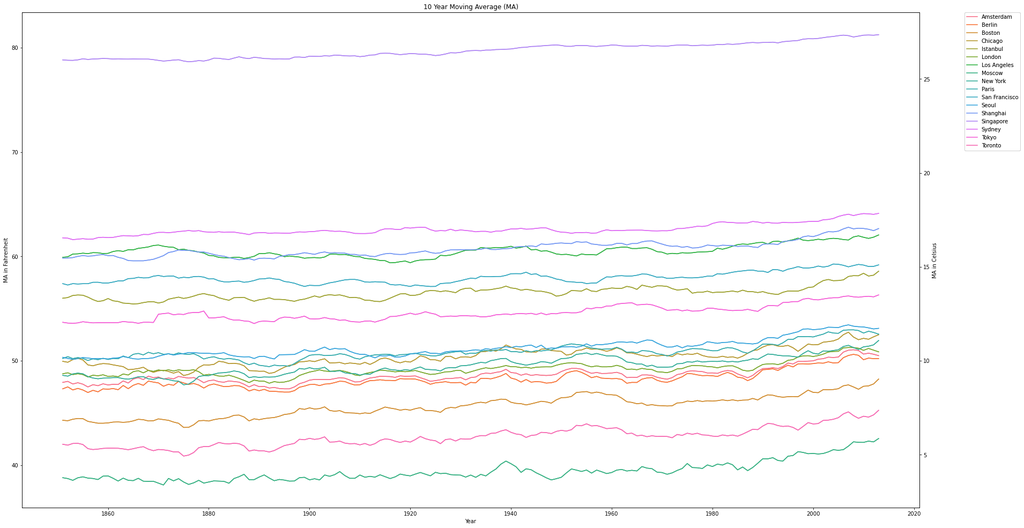

```python
a4_dims = (30, 17)
fig, ax = plt.subplots(figsize= a4_dims)

df = cd[cd.city_id.isin(best_cities.city_id) &(cd.year > 1850)]

plt.title("10 Year Moving Average (MA)")

plt.xlabel('Year')
plt.ylabel('MA in Fahrenheit')
sns.lineplot(x = df.year
             , y = df.MA10_F
             , data=df
             , ci=None
             , color='b'
             , hue='city'
            )

plt.legend(bbox_to_anchor=(1.05, 1), loc='upper left', borderaxespad=0.)
ax2 = plt.twinx()
plt.ylabel('MA in Celsius')
sns.lineplot(x = df.year
             , y = df.MA10_C
             , data=df
             , ci=None
             , color='r'
             , hue='city'
            )
plt.legend(bbox_to_anchor=(1.05, 1), loc='upper left', borderaxespad=0.)
plt.show()
```

### Insights from Graph 3 : Graph the moving averages of all the 'best cities' according to Wikipedia

- All the 17 cities tend to have very similar trending rates throughout time. They all seem to increase progressively. They also tend to not deviate too far from their prior yearly average temps
- Interestingly, the coldest 'best' city is Moscow, Russia, while the warmest is Singapore

# Graph 4 : Regression Plots for 17 Best Cities

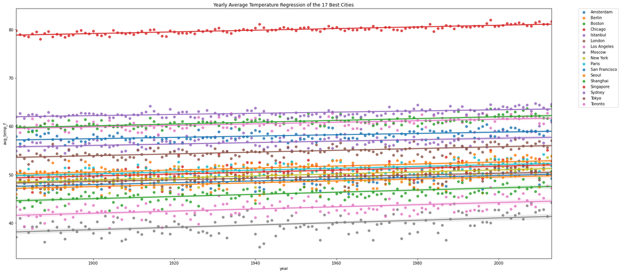

```python
a4_dims = (25, 12)
fig, ax = plt.subplots(figsize= a4_dims)

df = cd[cd.city_id.isin(best_cities.city_id) &(cd.year > 1880)]
dfgb = df.groupby('city_id')

plt.title('Yearly Average Temperature Regression of the 17 Best Cities')

for city_id, this_df in dfgb:

    city_name = cl[cl.city_id == city_id].city.item()
    this_plot = sns.regplot(x = this_df.year
             , y = this_df.avg_temp_f
             , data=this_df , label=city_name)

plt.legend(bbox_to_anchor=(1.05, 1), loc='upper left', borderaxespad=0.)
plt.show()
```

### Insights for Graph 4

- The regression plots more clearly show that every 'best city' across the world is increasing in warmth, year after year
- An interesting note is that a large ration of the 'best cities' have temperatures near the Global Average for that given year. Between 46-48 F */ 8-9 C*

##### The next set of Jupyter Cells call two APIs/Frameworks to generate the following data for additional observations

- geopy; for latitude / longitude information
- pycountry_convert; to get continent info

###### Since I have generated this previously, we can generate the dataframe from the pre-generated df of city_list_extended.csv

```python
cl = pd.read_csv('city_list_extended.csv', index_col=0)
```

```python
# retrieve longitutde and latitudes
from geopy.geocoders import Nominatim
geolocator = Nominatim(user_agent="udacity_p1_ladorable")

for index, city_info in cl.iterrows():
    city = city_info.city
    country = city_info.country
    # city_list country for Congo doesn't retrieve any results from Geopy, so we must clean/Transform this data
    if country == 'Congo (Democratic Republic Of The)':
        country = 'Congo'
    location = geolocator.geocode("{0},{1}".format(city, country))
#    print(city,country)
#    print(location.raw['lat'])
#    print(location.raw['lon'])
    cl.loc[index,'lat'] = location.raw['lat']
    cl.loc[index,'lon'] = location.raw['lon']
```

```python
# retrieve continent info
import pycountry_convert as pc

continents = {
    'NA': 'North America',
    'SA': 'South America',
    'AS': 'Asia',
    'OC': 'Australia',
    'AF': 'Africa',
    'EU': 'Europe'
}

for index, city_info in cl.iterrows():
    # The countries in the if statements below (not else) all have issues, so they must be interpreted/cleaned
    if(city_info.country == 'Guinea Bissau'):
        country_code = 'GW'
    elif(city_info.country == 'Bosnia And Herzegovina'):
        country_code = 'BA'
    elif(city_info.country == "Côte D'Ivoire"):
        country_code = 'CI'
    elif(city_info.country == "Congo (Democratic Republic Of The)"):
        country_code = pc.country_name_to_country_alpha2('Congo')
    else:
        country_code = pc.country_name_to_country_alpha2(city_info.country)

    continent_name = pc.country_alpha2_to_continent_code(country_code)
    cl.loc[index, 'continent'] = continents[continent_name]
```

```python
cl.set_index('city_id', inplace=True)
```

```python
cl.lat = cl.lat.astype('float32')
cl.lon = cl.lon.astype('float32')
```

```python
# save new city list info
cl.to_csv('city_list_extended.csv')
cl
```

| city_id | city | country | lat | lon | continent |
| --- | --- | --- | --- | --- | --- |
| 0 | Abidjan | Côte D'Ivoire | 5.320357 | -4.016107 | Africa |
| 1 | Abu Dhabi | United Arab Emirates | 24.453835 | 54.377403 | Asia |
| 2 | Abuja | Nigeria | 9.064330 | 7.489297 | Africa |
| 3 | Accra | Ghana | 5.560014 | -0.205744 | Africa |
| 4 | Adana | Turkey | 36.993618 | 35.325836 | Asia |
| ... | ... | ... | ... | ... | ... |
| 337 | Xuzhou | China | 34.206657 | 117.278290 | Asia |
| 338 | Yamoussoukro | Côte D'Ivoire | 6.809107 | -5.273263 | Africa |
| 339 | Yerevan | Armenia | 40.177612 | 44.512585 | Asia |
| 340 | Zagreb | Croatia | 45.813183 | 15.977178 | Europe |
| 341 | Zapopan | Mexico | 20.721121 | -103.391365 | North America |

342 rows × 5 columns

```python
# Get Average temperatures for ALL contintents and compare it to the global average
clcon_gb = cl.groupby('continent')
clcon_gb.groups

contintent_city_ids =  []

for continent, con_df in clcon_gb:
    contintent_dict = {
        'continent' : continent,
        'city_ids' : con_df.index
    }
    contintent_city_ids.append(contintent_dict)

ccdf = pd.DataFrame (contintent_city_ids)
ccdf.set_index('continent', inplace=True)
ccdf.to_csv('continent_city_ids.csv')
ccdf
```

| continent | city_ids |
| --- | --- |
| Africa | Int64Index([ 0, 2, 3, 9, 11, 18, 20,... |
| Asia | Int64Index([ 1, 4, 6, 7, 12, 13, 14,... |
| Australia | Int64Index([5, 51, 60, 197, 240, 248, 300, 331... |
| Europe | Int64Index([ 15, 22, 33, 38, 39, 42, 43,... |
| North America | Int64Index([ 8, 10, 19, 23, 24, 27, 46,... |
| South America | Int64Index([ 34, 35, 36, 40, 58, 59, 61,... |

```python
# go through each continent city groups, and generate an average of all their (per continent) temperatures by year, save as con_df
ccd_df_list = []
for index, cci in ccdf.iterrows():
    this_df = cd[cd.city_id.isin(cci.city_ids.to_list())]

    con_avg_df = this_df[['avg_temp', 'avg_temp_f', 'MA10_C', 'MA10_F', 'MA25_F', 'MA25_C', 'year']].groupby('year').mean().reset_index()
    con_avg_df['continent'] = index
    ccd_df_list.append( con_avg_df)
con_df = pd.concat(ccd_df_list)
con_df.to_csv('con_df.csv')
con_df
```

|  | year | avg_temp | avg_temp_f | MA10_C | MA10_F | MA25_F | MA25_C | continent |
| --- | --- | --- | --- | --- | --- | --- | --- | --- |
| 0 | 1743 | 14.720000 | 58.4960 | 14.720000 | 58.49600 | 58.496000 | 14.720000 | Africa |
| 1 | 1744 | 19.660000 | 67.3880 | 17.190000 | 62.94200 | 62.942000 | 17.190000 | Africa |
| 2 | 1745 | 11.820000 | 53.2760 | 15.400000 | 59.72000 | 59.720000 | 15.400000 | Africa |
| 3 | 1746 | NaN | NaN | 15.400000 | 59.72000 | 59.720000 | 15.400000 | Africa |
| 4 | 1747 | NaN | NaN | 15.400000 | 59.72000 | 59.720000 | 15.400000 | Africa |
| ... | ... | ... | ... | ... | ... | ... | ... | ... |
| 185 | 2009 | 21.781667 | 71.2070 | 21.593800 | 70.86884 | 70.656752 | 21.475973 | South America |
| 186 | 2010 | 21.739333 | 71.1308 | 21.647933 | 70.96628 | 70.703696 | 21.502053 | South America |
| 187 | 2011 | 21.445667 | 70.6022 | 21.628333 | 70.93100 | 70.715288 | 21.508493 | South America |
| 188 | 2012 | 21.802000 | 71.2436 | 21.629433 | 70.93298 | 70.724000 | 21.513333 | South America |
| 189 | 2013 | 21.332667 | 70.3988 | 21.592800 | 70.86704 | 70.738928 | 21.521627 | South America |

1447 rows × 8 columns

# Graph 5 : Plot Temperature Trends of each continent, for any meaninful observations

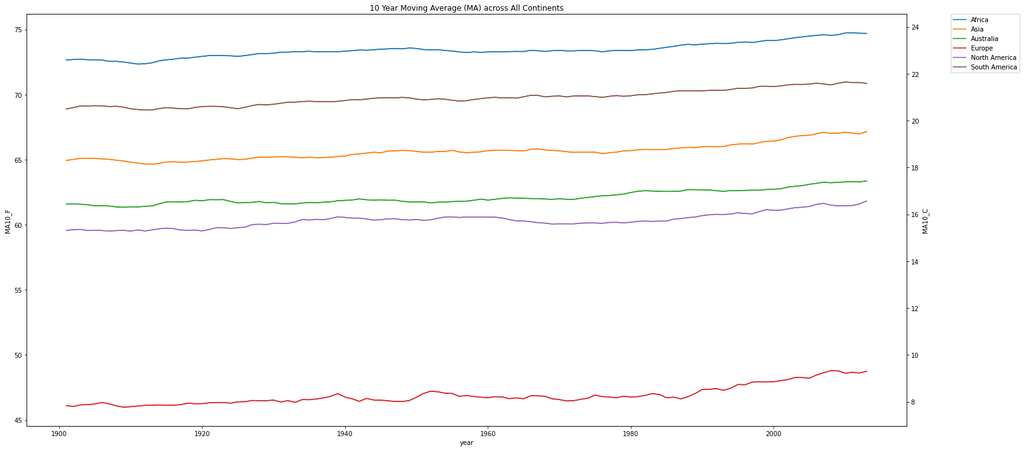

```python
a4_dims = (25, 12)
fig, ax = plt.subplots(figsize= a4_dims)

df = con_df[con_df.year > 1900]

plt.title("10 Year Moving Average (MA) across All Continents")
#plt.xlabel('Year')
#plt.ylabel('MA in Fahrenheit')
sns.lineplot(x = df.year
             , y = df.MA10_F
             , data=df
             , ci=None
             , color='b'
             , hue='continent'
            )
#
plt.legend(bbox_to_anchor=(1.05, 1), loc='upper left', borderaxespad=0.)
ax2 = plt.twinx()
#plt.ylabel('MA in Celsius')
sns.lineplot(x = df.year
             , y = df.MA10_C
             , data=df
             , ci=None
             , color='r'
             , hue='continent'
            )
plt.legend(bbox_to_anchor=(1.05, 1), loc='upper left', borderaxespad=0.)
plt.show()
```

# Graph 5 : Insights

- Coldest continent is Europe
- Warmest continent is Africa
- Although there has been a generally upward trend since 1900, the rate has significantly increased after 1980

### Hypthoesis: Does latitude near 0 (along the band of the equator ) have consistently higher temperatures, than elsewhere?

- For my next and final insight, I hope to figure out the weather it is true that all cities near the equator is hot. In my work after Graph 4 above, I retrieved the latitude and longitude data for every city in the city_data list using external API's and python packages

```python
# Found cities near the equator by searching for cities near 0 latitude, with a 4* latitude margin difference to lat == 0
cl_near_equator = cl[(cl.lat < 4)& (cl.lat > -4)]
cl_near_equator
```

| city_id | city | country | lat | lon | continent |
| --- | --- | --- | --- | --- | --- |
| 55 | Bujumbura | Burundi | -3.363812 | 29.367502 | Africa |
| 58 | Cali | Colombia | 3.451792 | -76.532494 | South America |
| 99 | Fortaleza | Brazil | -3.730451 | -38.521797 | South America |
| 110 | Guayaquil | Ecuador | -2.170414 | -79.905022 | South America |
| 143 | Kampala | Uganda | 0.317714 | 32.581352 | Africa |
| 154 | Kigali | Rwanda | -1.950851 | 30.061506 | Africa |
| 160 | Kuala Lumpur | Malaysia | 3.151696 | 101.694237 | Asia |
| 168 | Libreville | Gabon | 0.390002 | 9.454001 | Africa |
| 186 | Malabo | Equatorial Guinea | 3.752828 | 8.780061 | Africa |
| 189 | Manaus | Brazil | -3.131633 | -59.982506 | South America |
| 196 | Medan | Indonesia | 3.589665 | 98.673828 | Asia |
| 206 | Mogadishu | Somalia | 2.034931 | 45.341919 | Africa |
| 216 | Nairobi | Kenya | -1.303169 | 36.826061 | Africa |
| 235 | Palembang | Indonesia | -2.988830 | 104.756859 | Asia |
| 258 | Quito | Ecuador | -0.220164 | -78.512329 | South America |
| 283 | Santo Domingo | Ecuador | -0.340189 | -79.171547 | South America |
| 292 | Singapore | Singapore | 1.357107 | 103.819496 | Asia |

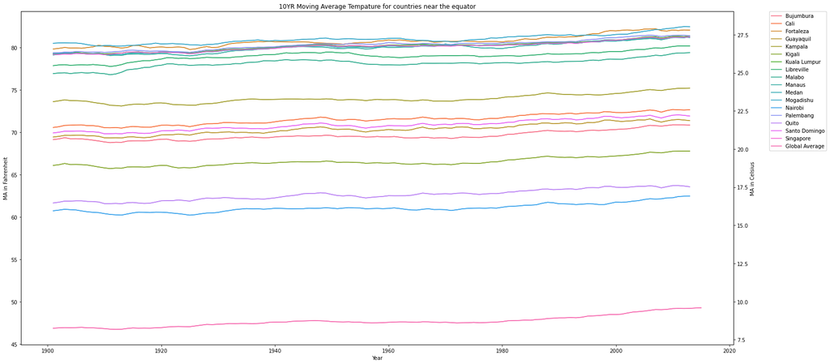

```python
fig, ax = plt.subplots(figsize= a4_dims)

region = 'Countries Near Equator'
df = cd[cd.city_id.isin(cl_near_equator.index.to_list())]
mdf = gd
mdf['city'] ='Global Average'
mdf = pd.concat([df,gd])
mdf = mdf[mdf.year > 1900]
#city = 'San Francisco'
#df = cd[cd.city == 'San Francisco']
#mdf = gd
#mdf['city'] ='Global'
#mdf = pd.concat([df,gd])

plt.title("10YR Moving Average Tempature for countries near the equator")
plt.xlabel('Year')
plt.ylabel('MA in Fahrenheit')
sns.lineplot(x = mdf.year
             , y = mdf.MA10_F
             , data=mdf
             , ci=None
             , color='b'
             , hue='city'
            )
plt.legend(bbox_to_anchor=(1.05, 1), loc='upper left', borderaxespad=0.)
ax2 = plt.twinx()
plt.ylabel('MA in Celsius')
sns.lineplot(x = mdf.year
             , y = mdf.MA10_C
             , data=mdf
             , ci=None
             , color='r'
             , hue='city'
            )
plt.legend(bbox_to_anchor=(1.05, 1), loc='upper left', borderaxespad=0.)
plt.show()
```

# Graph 6 : Insights

##### * So my original hypthoesis is close to being true. Notice, how the global average is much lower than all the equatorial cities.

##### * However, I found that two cities were not necessary very hot; Quito and Nairobi. This is because I forgot to consider elevation as a factor in determining temperature. Also, humidity, and precipitation was not considered in this dataset. In summary, this generally proves that cities near the equator are generally hot. I could improve the evidence of the claim, if I compare averages of cities across different 'bins' of latitudes.

### Conclusion

- I found this project very interesting and there are hundreds of more ways the data could be utilized interpretted and combined/juxtaposed with information to provide even more interesting insights.

# Environment Preperation Steps

```python
# Set up SQL string
import os
db = os.environ.get('LDB')
```

```python
# load sql magic
%load_ext sql
```

```
The sql extension is already loaded. To reload it, use:
  %reload_ext sql
```